[figure not shown]

# JDS Capstone: Target Market Analysis

Click here for the presentation file  
This capstone project was done after finishing the Junior Data Scientist program with CADS to showcase our skills that we have gained as well as to show completing projects within a team.  
You have been provided with information about the customers' historical purchase as the amount of money spent, Number of inactive months and so on. Two columns `Potential_Customer` and `Cust_Last_Purchase` represent the customers' respond to the latest advertisement. The column `Potential_Customer` represents if the customer purchased any product, and the column `Cust_Last_Purchase` represents the amount of this purchase and it is `Nan` if there has been no purchase.

## Data description

- Below is the description of each feature available in the dataset.

[figure not shown]

## Objective

**1. Design a predictive model to determine the potential customers who will purchase if you send the advertisement .** The target variable is `Potential_Customer`.

```
**Attention:** Because the column `Cust_Last_Purchase` relates to the target variable `Potential_Customer`, you need to exclude it from your model.
```

**2. Calculate the value and the revenue of your model.** Fit your model on train set. Assume amonge the customers on your test set we only send advertisement to those your model predicted as Class1 and we ignore the rest. From the data you can calculate the average `Cust_Last_Purchase` for those who are in the train set and had the last purchase (`Cust_Last_Purchase`>0) . Assume sending advertisement to each customer costs 5$ and the average purchase you calculated on the train set remains the same for the test set. Calculate the value of your models to choose the best model.

```
- cost = advertisement_cost * number of the predicted positive
- lost = average_purchase * number of the predicted negative but they have been positive
- gain = average_purchase * number of the predicted positive and they have been positive
- value = gain - lost - cost
- revenue = gain - cost
```

**3. Compare your best model's revenue with the revenue of the default solution which is sending advertisement to all the customers in X_test.** Which solution would you choose?

```
- cost = advertisement_cost * size of the test set
- gain = sum(Cust_Last_Purchase) on test set
- revenue = gain - cost
```

**4. Assume the next time you want to target a group of 30,000 customers simillar to this group. And assume the purchase rate is $10%$ which means 10 out of 100 people who receive the advertisement will purchase the product. Also assume your model will have the same Precision and Recall for Class1 .** Will you send the advertisement to everyone, or you use one of the models you have already created?

```
- calculate your model's revenue on this set of 30,000 customers based on the above assumptions
- calculate the revenue of the default model: send advertisement to everyone
     - cost = advertisement_cost * size of the test set
     - gain = average_purchase * purchase_rate
     - revenue = gain - cost
```

**Hint:** To calculate the revenue of a model for this new set of customers with different purchase rate we need to calculate the new confusion matrix given Precision and Recall for Class1 are fixed.

## Submission Guideline

Perform the following:

1. Create a team (2-3 people)
2. Perform the following:
   1. **Data Wrangling - Cleaning & Merging**: Check and handle the existance of missing values, the type of variables, or integrity of data
   2. **Exploratory Data Analysis**: Analyze data to summarize their main characteristics
   3. **Feature Engineering**: Make new features or change the current features
   4. **Feature Selection**: Choose the best features
   5. **Data Pre-Processing**: Make data usable for applying ML algorithms.
   6. **Model Design**: Create several predictive models and tune the hyperparameters
   7. **Model Evaluation**: Compare the performance of the models
   8. **Bonus**: Any creative idea for improving machine learning models

The output expected at the end of this capstone is:

1. One **Jupyter notebook** containing all analysis performed using Python.
2. One **PowerPoint** presentation containing the analysis results. Each group will be allocated 15-20 minutes (inclusive of Q&A) to present their analysis results to the class.

**One zip file per group** is to be uploaded on **GDrive** by the **time** that will be given to you by the trainer, including the **jupyter notebook(s)** and the **powerpoint presentation** indicating the **names of all group members**.

## Presentation Guideline

**Note(s):**

1. Only **one submission** is required per group.
2. Include full details in your notebook and **report only important results** in your presentation.
3. Please only use Jupyter notebook (pandas) to clean the data (Do not clean manually using Excel)

# Table of Content

- JDS Capstone: Target Market Analysis
- Data description
- Objective
- Submission Guideline
- Presentation Guideline
- Table of Content
- 0. Import necessary Packages
- 1. Load the Data into Pandas Dataframe
- 2. Data Cleaning
  - 2.1 How big is the dataset? (number of rows, features and total datapoints)
  - 2.2 What is the type of each column?
    - 2.2.1 Why columns such as `Cust_Last_Purchase` are `object` while they should be `float64`? Fix the type of the columns as it should be.
  - 2.3 Check data for duplicate rows and remove the duplicates
  - 2.4 Do we need `C_ID` in our analysis? Drop the columns you will not use in your analysis, if there is any.
- 3. Exploratory Data Analysis (EDA)
  - 3.1 Explore Categorical Variables
    - 3.1.1 Insight
    - 3.1.2 Solution
  - 3.2 Explore Relationship Between Categorical & Target Variable. Interpret the observation
    - 3.2.1. Insight
  - 3.3 Explore Numerical Variables
    - 3.3.1 Insight
  - 3.4 Explore the Relationship between Numerical Variables & Target Variable. Interpret your observation
  - 3.5 Explore the Relationship between the columns and try to answer the following questions:
- 4. Feature Enginearing
  - 4.1 Add Some High Level Features and explore their relationship with the target variable
  - 4.2 Check Correlation between Numerical Variables
- 5. Feature Selection
- 6. Data PreProcessing
  - 6.1 Check the Data for Missing Values
  - 6.2 Separate X (features) and y (target)
  - 6.3 Split data to train/test
  - 6.4 Dummy Variables
  - 6.5 Feature Scaling
  - 6.6 PCA on Numerical Columns only
- 7. Objective 1: Machine Learning
- 8. Objective 2
- 9. Objective 3
- 10. Objective 4

# 0. Import necessary Packages

```python
# Importing relevant packages
import pandas as pd
import numpy as np
import matplotlib.pyplot as plt
import seaborn as sns

from sklearn.linear_model import LogisticRegression
from sklearn.ensemble import RandomForestClassifier, GradientBoostingClassifier
from sklearn.neighbors import KNeighborsClassifier
from sklearn.tree import DecisionTreeClassifier
from sklearn.svm import SVC
from sklearn.model_selection import train_test_split
from sklearn.metrics import confusion_matrix
from sklearn.preprocessing import StandardScaler
from sklearn.model_selection import GridSearchCV
from sklearn.metrics import recall_score, precision_score, f1_score
from sklearn.model_selection import cross_val_score
from sklearn.model_selection import cross_val_predict
from sklearn.metrics import classification_report
from sklearn.neural_network import MLPClassifier
from sklearn.model_selection import cross_val_score, GridSearchCV
from sklearn.metrics import accuracy_score, roc_auc_score, f1_score
from sklearn.metrics import accuracy_score
import warnings
warnings.filterwarnings("ignore")
```

# 1. Load the Data into Pandas Dataframe

```python
# Load the data into data dataframe
data = pd.read_csv('../data.csv')
```

```python
# View first 5 rows of dataframe
data.head()
```

|  | Potential_Customer | C_ID | Cust_Last_Purchase | Pur_3_years | Pur_5_years | Pur_3_years_Indirect | Pur_5_years_Indirect | Pur_latest | Pur_3_years_Avg | Pur_5_years_Avg | ... | Ad_Res_5_Year | Ad_Res_Ind_1_Year | Ad_Res_Ind_3_Year | Ad_Res_Ind_5_Year | Status_Cust | Status_Latest_Ad | Age | Gender | Cust_Prop | Cust_Ann_Income |
| --- | --- | --- | --- | --- | --- | --- | --- | --- | --- | --- | --- | --- | --- | --- | --- | --- | --- | --- | --- | --- | --- |
| 0 | 1 | 9946 | $5.00 | 2 | 17 | 2 | 4 | $0.00 | $7.50 | $7.76 | ... | 73 | 3 | 12 | 16 | A | 0 | 71.0 | F | H | $65,957.00 |
| 1 | 1 | 87939 | $30.00 | 1 | 7 | 0 | 3 | $25.00 | $25.00 | $13.00 | ... | 55 | 6 | 6 | 22 | A | 1 | 7.0 | M | U | $0.00 |
| 2 | 0 | 88003 | NaN | 5 | 12 | 3 | 5 | $15.00 | $15.00 | $11.25 | ... | 53 | 6 | 17 | 22 | S | 1 | 79.0 | F | U | $0.00 |
| 3 | 1 | 188721 | $20.00 | 1 | 11 | 0 | 3 | $20.00 | $20.00 | $12.45 | ... | 71 | 8 | 8 | 33 | A | 0 | 73.0 | F | U | $76,293.00 |
| 4 | 1 | 88056 | $5.00 | 3 | 15 | 2 | 7 | $3.00 | $4.33 | $3.80 | ... | 63 | 6 | 12 | 24 | S | 1 | 68.0 | F | H | $113,663.00 |

5 rows × 25 columns

```python
# View your data
data.describe().T
```

|  | count | mean | std | min | 25% | 50% | 75% | max |
| --- | --- | --- | --- | --- | --- | --- | --- | --- |
| Potential_Customer | 4469.0 | 0.480868 | 0.499690 | 0.0 | 0.0 | 0.0 | 1.0 | 1.0 |
| C_ID | 4469.0 | 73837.719848 | 36156.968605 | 12.0 | 52713.0 | 75790.0 | 93705.0 | 191672.0 |
| Pur_3_years | 4469.0 | 3.297158 | 2.207326 | 0.0 | 2.0 | 3.0 | 4.0 | 15.0 |
| Pur_5_years | 4469.0 | 11.006042 | 9.459082 | 1.0 | 4.0 | 9.0 | 15.0 | 91.0 |
| Pur_3_years_Indirect | 4469.0 | 1.897516 | 1.629178 | 0.0 | 1.0 | 2.0 | 3.0 | 9.0 |
| Pur_5_years_Indirect | 4469.0 | 5.867756 | 4.939174 | 0.0 | 2.0 | 4.0 | 9.0 | 41.0 |
| InAct_Last | 4469.0 | 17.923697 | 4.130671 | 4.0 | 16.0 | 18.0 | 20.0 | 27.0 |
| InAct_First | 4469.0 | 73.605952 | 38.094688 | 15.0 | 40.0 | 74.0 | 111.0 | 260.0 |
| Ad_Res_1_year | 4469.0 | 13.070038 | 4.991064 | 3.0 | 11.0 | 12.0 | 13.0 | 49.0 |
| Ad_Res_3_Year | 4469.0 | 29.631237 | 7.787209 | 5.0 | 26.0 | 31.0 | 34.0 | 71.0 |
| Ad_Res_5_Year | 4469.0 | 49.683822 | 23.056042 | 7.0 | 31.0 | 51.0 | 66.0 | 157.0 |
| Ad_Res_Ind_1_Year | 4469.0 | 5.406355 | 1.361155 | 1.0 | 5.0 | 6.0 | 6.0 | 17.0 |
| Ad_Res_Ind_3_Year | 4469.0 | 12.045872 | 4.586081 | 2.0 | 7.0 | 13.0 | 16.0 | 28.0 |
| Ad_Res_Ind_5_Year | 4469.0 | 19.496979 | 8.580510 | 3.0 | 13.0 | 20.0 | 27.0 | 56.0 |
| Status_Latest_Ad | 4469.0 | 0.562094 | 0.496185 | 0.0 | 0.0 | 1.0 | 1.0 | 1.0 |
| Age | 3510.0 | 59.020228 | 16.902682 | 0.0 | 47.0 | 60.0 | 73.0 | 87.0 |

# 2. Data Cleaning

Checking the existance of missing values, the type of variables, or integrity of data.

## 2.1 How big is the dataset? (number of rows, features and total datapoints)

```python
print("rows and column =",data.shape)
```

```
rows and column = (4469, 25)
```

## 2.2 What is the type of each column?

```python
data.dtypes
```

```
Potential_Customer            int64
C_ID                          int64
Cust_Last_Purchase           object
Pur_3_years                   int64
Pur_5_years                   int64
Pur_3_years_Indirect          int64
Pur_5_years_Indirect          int64
Pur_latest                   object
Pur_3_years_Avg              object
Pur_5_years_Avg              object
Pur_3_years_Avg_Indirect     object
InAct_Last                    int64
InAct_First                   int64
Ad_Res_1_year                 int64
Ad_Res_3_Year                 int64
Ad_Res_5_Year                 int64
Ad_Res_Ind_1_Year             int64
Ad_Res_Ind_3_Year             int64
Ad_Res_Ind_5_Year             int64
Status_Cust                  object
Status_Latest_Ad              int64
Age                         float64
Gender                       object
Cust_Prop                    object
Cust_Ann_Income              object
dtype: object
```

### 2.2.1 Why columns such as `Cust_Last_Purchase` are `object` while they should be `float64`? Fix the type of the columns as it should be.

**Attention:** Some numerical columns have missing values, Dollar sign, or Comma. You need to fix the issue to be able to convert the column to numerical.

**Hint:**

1. The following code can help you to remove an 'OldSign' and replace it with a 'NewSign' or nothing: `df.col=df.col.str.replace('OldSign', 'NewSign')`
2. After removing the signs and replace it with correct sign, or nothing you need to:

   a- Create a list of the name of the categorical columns and the numerical columns: `CatCols=[Name of the Categorical columns]` `NumCols=list(set(data.columns)-set(CatCols))`

   b- Fix the type of the columns `data[CatCols] = data[CatCols].apply(lambda x: x.astype('category'))` `data[NumCols] = data[NumCols].apply(lambda x: x.astype('float64'))`

```python
# check type of object in respective columns

data_columns_obj = (["Cust_Last_Purchase", "Pur_latest", "Pur_3_years_Avg",
                     "Pur_5_years_Avg", "Pur_3_years_Avg_Indirect", "Status_Cust",
                     "Gender", "Cust_Prop", "Cust_Ann_Income"])

for x in data_columns_obj:
    print("Column:", x)
    print(data[x])
    print()


# Here we found the object type is $ and comma (,)
```

```
Column: Cust_Last_Purchase
0        $5.00
1       $30.00
2           NaN
3       $20.00
4        $5.00
         ...
4464     $5.00
4465     $5.00
4466    $10.00
4467     $5.00
4468        NaN
Name: Cust_Last_Purchase, Length: 4469, dtype: object

Column: Pur_latest
```

[output cut: 110 more lines]

```python
# we need to replace $ and comma (,) with empty string

for x in data_columns_obj:
    data[x] = data[x].str.replace("$", "")
    data[x] = data[x].str.replace(",", "")
```

```python
data.head()
```

|  | Potential_Customer | C_ID | Cust_Last_Purchase | Pur_3_years | Pur_5_years | Pur_3_years_Indirect | Pur_5_years_Indirect | Pur_latest | Pur_3_years_Avg | Pur_5_years_Avg | ... | Ad_Res_5_Year | Ad_Res_Ind_1_Year | Ad_Res_Ind_3_Year | Ad_Res_Ind_5_Year | Status_Cust | Status_Latest_Ad | Age | Gender | Cust_Prop | Cust_Ann_Income |
| --- | --- | --- | --- | --- | --- | --- | --- | --- | --- | --- | --- | --- | --- | --- | --- | --- | --- | --- | --- | --- | --- |
| 0 | 1 | 9946 | 5.00 | 2 | 17 | 2 | 4 | 0.00 | 7.50 | 7.76 | ... | 73 | 3 | 12 | 16 | A | 0 | 71.0 | F | H | 65957.00 |
| 1 | 1 | 87939 | 30.00 | 1 | 7 | 0 | 3 | 25.00 | 25.00 | 13.00 | ... | 55 | 6 | 6 | 22 | A | 1 | 7.0 | M | U | 0.00 |
| 2 | 0 | 88003 | NaN | 5 | 12 | 3 | 5 | 15.00 | 15.00 | 11.25 | ... | 53 | 6 | 17 | 22 | S | 1 | 79.0 | F | U | 0.00 |
| 3 | 1 | 188721 | 20.00 | 1 | 11 | 0 | 3 | 20.00 | 20.00 | 12.45 | ... | 71 | 8 | 8 | 33 | A | 0 | 73.0 | F | U | 76293.00 |
| 4 | 1 | 88056 | 5.00 | 3 | 15 | 2 | 7 | 3.00 | 4.33 | 3.80 | ... | 63 | 6 | 12 | 24 | S | 1 | 68.0 | F | H | 113663.00 |

5 rows × 25 columns

```python
# set the categorical data
# Potential_Customer and Status_Latest_Ad is binary (1,0) = thus it is categorical

categorical_cols = (["Potential_Customer", "Status_Cust", "Status_Latest_Ad", "Gender", "Cust_Prop"])

data[categorical_cols] = data[categorical_cols].astype("category")
```

```python
numerical_cols = ['C_ID', 'Cust_Last_Purchase', 'Pur_3_years', 'Pur_5_years',
                  'Pur_3_years_Indirect', 'Pur_5_years_Indirect', 'Pur_latest',
                  'Pur_3_years_Avg', 'Pur_5_years_Avg', 'Pur_3_years_Avg_Indirect',
                  'InAct_Last', 'InAct_First', 'Ad_Res_1_year', 'Ad_Res_3_Year',
                  'Ad_Res_5_Year', 'Ad_Res_Ind_1_Year', 'Ad_Res_Ind_3_Year',
                  'Ad_Res_Ind_5_Year', 'Age', 'Cust_Ann_Income']

data[numerical_cols] = data[numerical_cols].astype("float64")
```

```python
data.info()
```

```
<class 'pandas.core.frame.DataFrame'>
RangeIndex: 4469 entries, 0 to 4468
Data columns (total 25 columns):
 #   Column                    Non-Null Count  Dtype
---  ------                    --------------  -----
 0   Potential_Customer        4469 non-null   category
 1   C_ID                      4469 non-null   float64
 2   Cust_Last_Purchase        2149 non-null   float64
 3   Pur_3_years               4469 non-null   float64
 4   Pur_5_years               4469 non-null   float64
 5   Pur_3_years_Indirect      4469 non-null   float64
 6   Pur_5_years_Indirect      4469 non-null   float64
 7   Pur_latest                4469 non-null   float64
 8   Pur_3_years_Avg           4469 non-null   float64
 9   Pur_5_years_Avg           4469 non-null   float64
```

[output cut: 17 more lines]

## 2.3 Check data for duplicate rows and remove the duplicates

**Hint:**

1. `data.duplicated()` will give you `True` if the row in `data` is duplicate and `False` otherwise.
2. `duplicates.sum()` will tell you how many duplicates you have in `data`.
3. `data=data.drop_duplicates()` will remove the duplicates

```python
data.duplicated().sum()
```

```
851
```

```python
data = data.drop_duplicates()
```

```python
data.duplicated().sum()
```

```
0
```

```python
# check dimension of the data after removing the duplicates

print('Dimensions of data:', data.shape)
```

```
Dimensions of data: (3618, 25)
```

```python
data.head()
```

|  | Potential_Customer | C_ID | Cust_Last_Purchase | Pur_3_years | Pur_5_years | Pur_3_years_Indirect | Pur_5_years_Indirect | Pur_latest | Pur_3_years_Avg | Pur_5_years_Avg | ... | Ad_Res_5_Year | Ad_Res_Ind_1_Year | Ad_Res_Ind_3_Year | Ad_Res_Ind_5_Year | Status_Cust | Status_Latest_Ad | Age | Gender | Cust_Prop | Cust_Ann_Income |
| --- | --- | --- | --- | --- | --- | --- | --- | --- | --- | --- | --- | --- | --- | --- | --- | --- | --- | --- | --- | --- | --- |
| 0 | 1 | 9946.0 | 5.0 | 2.0 | 17.0 | 2.0 | 4.0 | 0.0 | 7.50 | 7.76 | ... | 73.0 | 3.0 | 12.0 | 16.0 | A | 0 | 71.0 | F | H | 65957.0 |
| 1 | 1 | 87939.0 | 30.0 | 1.0 | 7.0 | 0.0 | 3.0 | 25.0 | 25.00 | 13.00 | ... | 55.0 | 6.0 | 6.0 | 22.0 | A | 1 | 7.0 | M | U | 0.0 |
| 2 | 0 | 88003.0 | NaN | 5.0 | 12.0 | 3.0 | 5.0 | 15.0 | 15.00 | 11.25 | ... | 53.0 | 6.0 | 17.0 | 22.0 | S | 1 | 79.0 | F | U | 0.0 |
| 3 | 1 | 188721.0 | 20.0 | 1.0 | 11.0 | 0.0 | 3.0 | 20.0 | 20.00 | 12.45 | ... | 71.0 | 8.0 | 8.0 | 33.0 | A | 0 | 73.0 | F | U | 76293.0 |
| 4 | 1 | 88056.0 | 5.0 | 3.0 | 15.0 | 2.0 | 7.0 | 3.0 | 4.33 | 3.80 | ... | 63.0 | 6.0 | 12.0 | 24.0 | S | 1 | 68.0 | F | H | 113663.0 |

5 rows × 25 columns

## 2.4 Do we need `C_ID` in our analysis? Drop the columns you will not use in your analysis, if there is any.

**Hint:**

1. Drop the useless column(s)
2. Remove the name of the column(s) from `CatCols` or `NumCols` Example: CatCols.remove('C_ID')

```python
# we don't need customer id for our analysis,thus we will remove "C_ID"
# axis=1 argument indicates that we want to drop a column

data = data.drop('C_ID', axis=1)
```

```python
# don't forget to remove also in our numerical_cols

numerical_cols.remove("C_ID")
```

```python
# check

numerical_cols
```

```
['Cust_Last_Purchase',
 'Pur_3_years',
 'Pur_5_years',
 'Pur_3_years_Indirect',
 'Pur_5_years_Indirect',
 'Pur_latest',
 'Pur_3_years_Avg',
 'Pur_5_years_Avg',
 'Pur_3_years_Avg_Indirect',
 'InAct_Last',
 'InAct_First',
 'Ad_Res_1_year',
 'Ad_Res_3_Year',
 'Ad_Res_5_Year',
 'Ad_Res_Ind_1_Year',
 'Ad_Res_Ind_3_Year',
 'Ad_Res_Ind_5_Year',
 'Age',
 'Cust_Ann_Income']
```

# 3. Exploratory Data Analysis (EDA)

Checking the relationship betweem variables, summary of data, outliers, filling missing values etc. **If the ultimate goal is designing predictive models on the data, and we use EDA as part of the proprocessing, we are NOT allowed to do EDA on the test set.** However, if you only do EDA to get business insight from the data, you **CAN** use the whole data, if you don't use that insight for data preprocessing such as data cleaning.

**Example:** To impute the missing values by mean/median, we calculate the mean or the median on the Train set only and then we impute the missing values by that mean/median on both Train and Test data.

1. How many categories in each categorical variables?
2. What proportion/percentage from each category?

**Hint:** For visualization you can use `sns.countplot()` for each categorical variable

```python
data.describe(include=("category"))
```

|  | Potential_Customer | Status_Cust | Status_Latest_Ad | Gender | Cust_Prop |
| --- | --- | --- | --- | --- | --- |
| count | 3618 | 3618 | 3618 | 3618 | 3618 |
| unique | 2 | 6 | 2 | 3 | 2 |
| top | 0 | A | 1 | F | H |
| freq | 1882 | 2146 | 2057 | 1922 | 1981 |

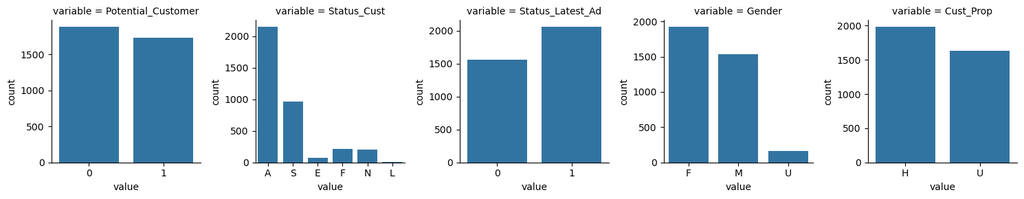

```python
# for own reference
# below code is given in PyDSTAT02_Distributions

import seaborn as sns

categorical_cols = ["Potential_Customer", "Status_Cust", "Status_Latest_Ad", "Gender", "Cust_Prop"]

catcols = pd.melt(data, value_vars=categorical_cols) # melt = wide format --> long

g = sns.FacetGrid(catcols, col="variable", sharex=False, sharey=False) # sharex sharey = False = axes x and y should not being shared across plots
g.map(sns.countplot, "value")
g.savefig("categorical.png", dpi=300)
```

```python
from tabulate import tabulate

for x in categorical_cols:

    cat_prop = data[x].value_counts()
    cat_perc = (data[x].value_counts(normalize=True)*100).round(2)

    table = tabulate({"Category": cat_prop.index,

                      "Percentage": cat_perc},
                     headers=["Category", f"Count of {x}", f"Percentage of {x}"],
                     showindex=False, tablefmt="fancy_grid")

    print(f"{x}\n{table}\n")
```

```
Potential_Customer
╒════════════╤═══════════════════════════════╕
│   Category │   Count of Potential_Customer │
╞════════════╪═══════════════════════════════╡
│          0 │                         52.02 │
├────────────┼───────────────────────────────┤
│          1 │                         47.98 │
╘════════════╧═══════════════════════════════╛

Status_Cust
╒════════════╤════════════════════════╕
│ Category   │   Count of Status_Cust │
╞════════════╪════════════════════════╡
│ A          │                  59.31 │
├────────────┼────────────────────────┤
│ S          │                  26.64 │
├────────────┼────────────────────────┤
│ F          │                   6.05 │
├────────────┼────────────────────────┤
│ N          │                   5.72 │
├────────────┼────────────────────────┤
│ E          │                   1.99 │
├────────────┼────────────────────────┤
│ L          │                   0.28 │
╘════════════╧════════════════════════╛

Status_Latest_Ad
╒════════════╤═════════════════════════════╕
│   Category │   Count of Status_Latest_Ad │
╞════════════╪═════════════════════════════╡
│          1 │                       56.85 │
├────────────┼─────────────────────────────┤
│          0 │                       43.15 │
╘════════════╧═════════════════════════════╛

Gender
╒════════════╤═══════════════════╕
│ Category   │   Count of Gender │
╞════════════╪═══════════════════╡
│ F          │             53.12 │
├────────────┼───────────────────┤
│ M          │             42.29 │
├────────────┼───────────────────┤
│ U          │              4.59 │
╘════════════╧═══════════════════╛

Cust_Prop
╒════════════╤══════════════════════╕
│ Category   │   Count of Cust_Prop │
╞════════════╪══════════════════════╡
│ H          │                54.75 │
├────────────┼──────────────────────┤
│ U          │                45.25 │
╘════════════╧══════════════════════╛
```

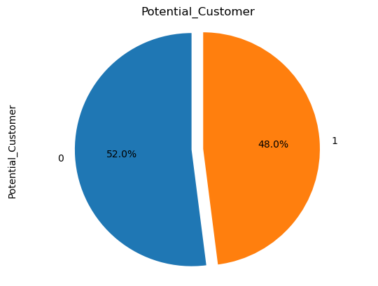

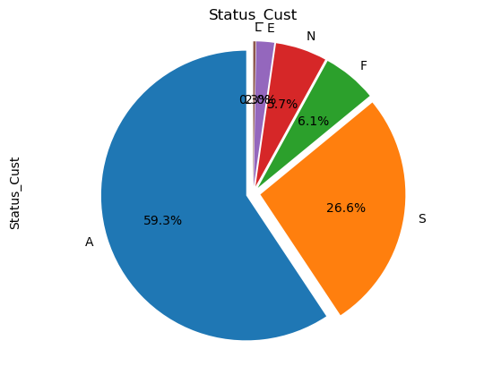

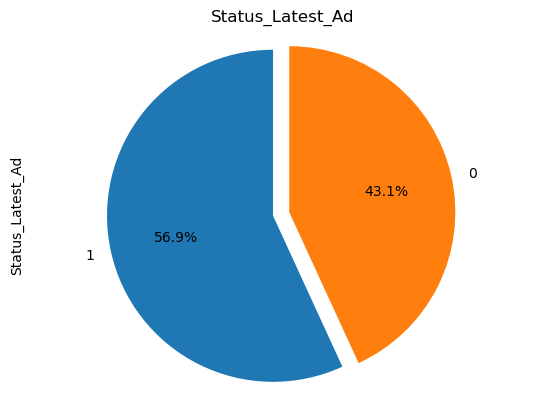

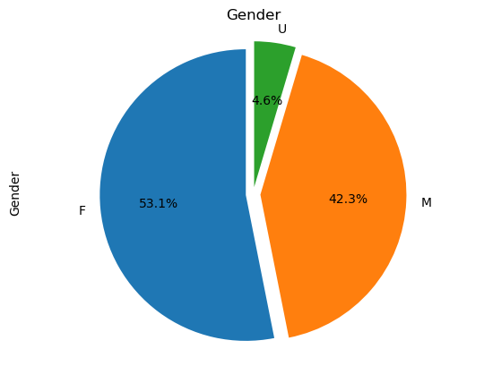

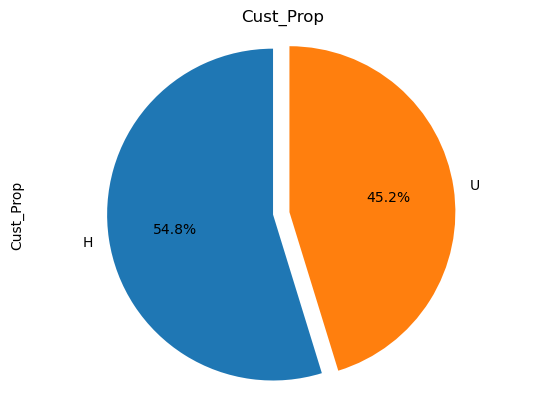

```python
import matplotlib.pyplot as plt

for x in categorical_cols:
    cat_prop = data[x].value_counts()
    cat_prop.plot(kind='pie', autopct='%1.1f%%', startangle=90, explode=[0.05]*len(cat_prop))
    plt.axis('equal')
    plt.title(x)
    plt.savefig(f"{x}.png")
    plt.show()
```

### 3.1.1 Insight

the data is imbalanced for Status_Cust

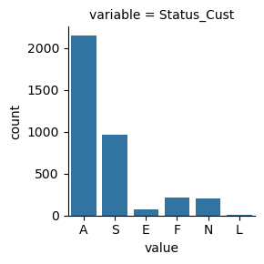

```python
categorical_cols_imb = ["Status_Cust"]

catcols = pd.melt(data, value_vars=categorical_cols_imb)

g = sns.FacetGrid(catcols, col="variable", sharex=False, sharey=False)
g.map(sns.countplot, "value")
plt.show()
```

### 3.1.2 Solution

let's group the value to balance the data

```python
new_value = {'A':'A',
             'S':'S',
             'E':'Others',
             'F':'Others',
             'N':'Others',
             'L':'Others'}

data['Status_Cust'] = data['Status_Cust'].replace(new_value)
data['Status_Cust'].unique()
```

```
['A', 'S', 'Others']
Categories (3, object): ['A', 'Others', 'S']
```

## 3.2 Explore Relationship Between Categorical & Target Variable. Interpret the observation

**Hint**:

1. Create list of the categorical features: `CatFes=list(set(CatCols)-set(['Potential_Customer']))`
2. use `sns.countplot()` to create subplots for each categorical feature and hue=`data.Potential_Customer` to assign color to the plot based on the target variable `Potential_Customer`

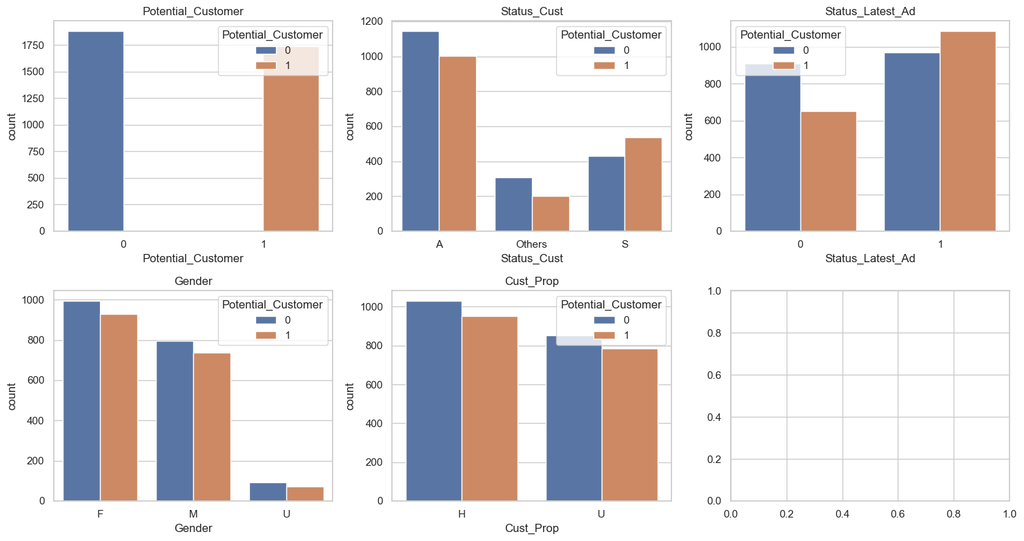

```python
import matplotlib.pyplot as plt
import seaborn as sns

fig, axs = plt.subplots(nrows=2, ncols=3, figsize=(15, 8))
sns.set(style='whitegrid')

for i, k in enumerate(categorical_cols):
    row, col = divmod(i, 3)
    ax = axs[row, col]
    sns.countplot(x=k,
                  hue='Potential_Customer',
                  data=data,
                  ax=ax)
    ax.set_title(k)

plt.tight_layout()

# Save the plot in one png
plt.savefig('categorical-target', dpi=300, bbox_inches='tight')

plt.show()
```

### 3.2.1. Insight

```python
# status cust new has relationship with target variable
# status latest ad has relationship with target variable
```

## 3.3 Explore Numerical Variables

**Hint**: use `sns.distplot()` and `sns.boxplot()`

```python
# fig,ax = plt.subplots(nrows=len(numerical_cols), ncols=2, figsize=(20,60))

# for num in range (len(numerical_cols)):
#     sns.displot(data[numerical_cols[num]], ax=ax[num,0])
#     sns.boxplot(data[numerical_cols[num]], ax=ax[num,1])

# plt.tight_layout()
# plt.show()
# plt.subplots_adjust(wspace=0.4, hspace=0.4)
```

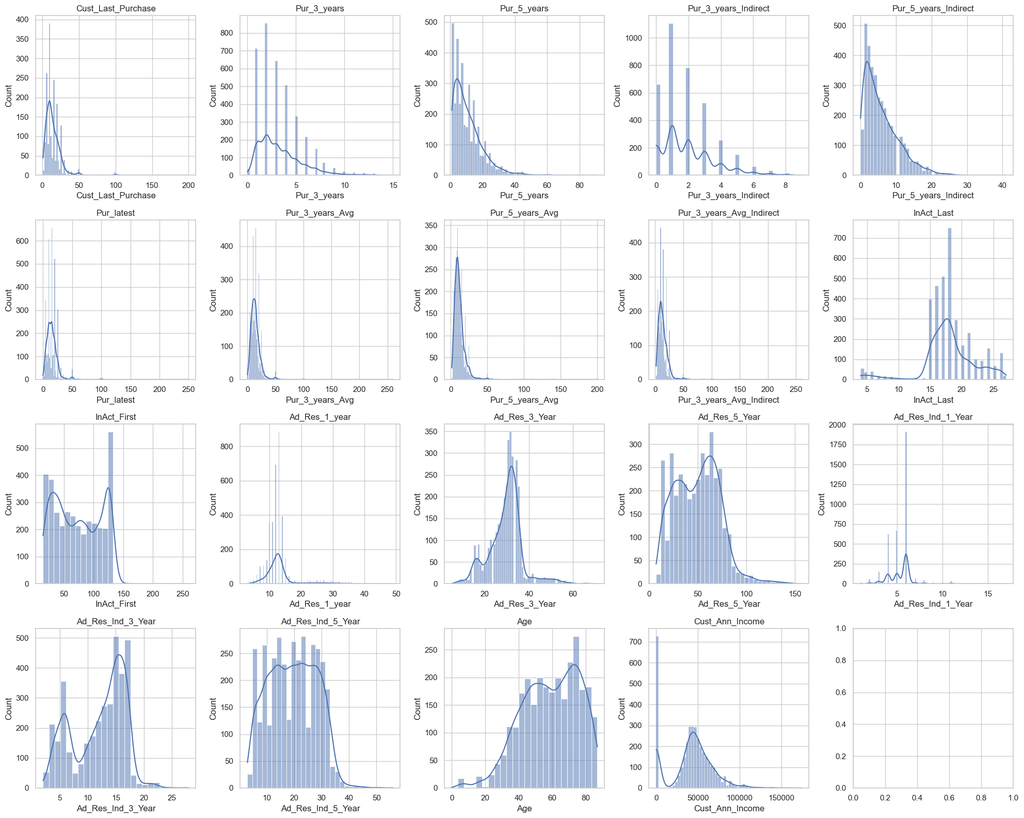

[figure not shown]

```python
import matplotlib.pyplot as plt
import seaborn as sns

fig, axes = plt.subplots(nrows=4, ncols=5, figsize=(20,16))
axes = axes.ravel()

for i, k in enumerate(numerical_cols):
    sns.histplot(data=data, x=k, kde=True, ax=axes[i])
    axes[i].set_title(k)

plt.tight_layout()

# Save figure
plt.savefig('numerical_histograms.png')
plt.show()
```

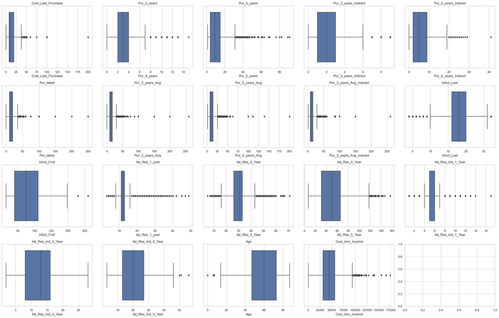

[figure not shown]

```python
import matplotlib.pyplot as plt
import seaborn as sns

fig, axes = plt.subplots(nrows=4, ncols=5, figsize=(25,16))
axes = axes.ravel()

for i, k in enumerate(numerical_cols):
    sns.boxplot(data=data, x=k, ax=axes[i])
    axes[i].set_title(k)

plt.tight_layout()

# Save figure
plt.savefig('numerical_boxplots.png')
plt.show()
```

### 3.3.1 Insight

```python
# based on histplot with kde curve,we will check for skewness for further analysis in data imputation
# based on boxplot, majority of data has outliers,we will check for integrity of outliers for future analysis in data amputation
#
#
#
```

## 3.4 Explore the Relationship between Numerical Variables & Target Variable. Interpret your observation

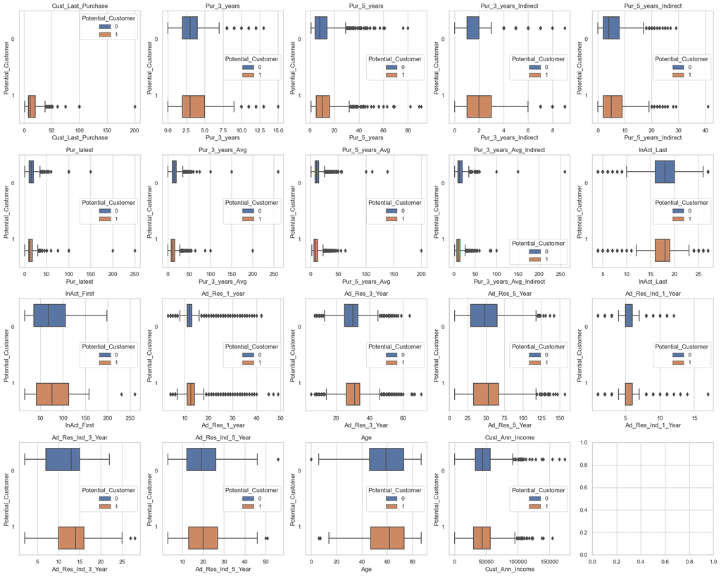

```python
# our target variable is potential customer

fig, axes = plt.subplots(nrows=4, ncols=5, figsize=(20,16))
axes = axes.ravel()

for k, i in zip(numerical_cols, axes):
    sns.boxplot(data=data,
                x=k,
                y="Potential_Customer",
                hue="Potential_Customer",
                ax=i)
    i.set_title(k)

plt.tight_layout()
plt.show()
```

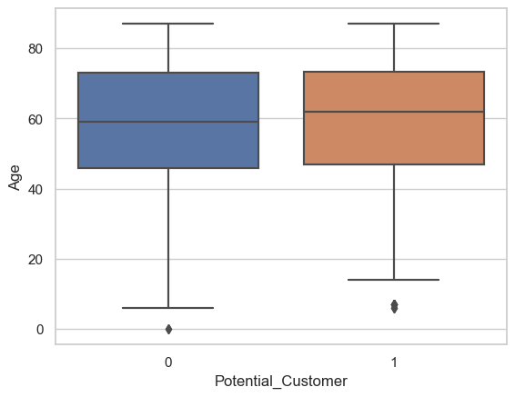

```python
sns.boxplot(x=data["Potential_Customer"], y=data["Age"], data=data)
plt.show()
```

```python
data.columns
```

```
Index(['Potential_Customer', 'Cust_Last_Purchase', 'Pur_3_years',
       'Pur_5_years', 'Pur_3_years_Indirect', 'Pur_5_years_Indirect',
       'Pur_latest', 'Pur_3_years_Avg', 'Pur_5_years_Avg',
       'Pur_3_years_Avg_Indirect', 'InAct_Last', 'InAct_First',
       'Ad_Res_1_year', 'Ad_Res_3_Year', 'Ad_Res_5_Year', 'Ad_Res_Ind_1_Year',
       'Ad_Res_Ind_3_Year', 'Ad_Res_Ind_5_Year', 'Status_Cust',
       'Status_Latest_Ad', 'Age', 'Gender', 'Cust_Prop', 'Cust_Ann_Income'],
      dtype='object')
```

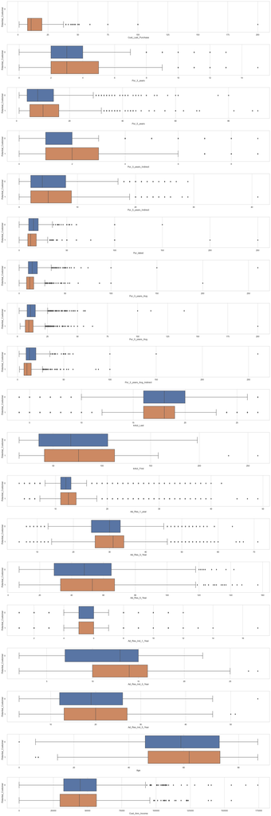

```python
import matplotlib.pyplot as plt
import seaborn as sns

fig, ax = plt.subplots(nrows=len(numerical_cols),ncols=1, figsize=(20,60))

for num in range(len(numerical_cols)):
    sns.boxplot(x=numerical_cols[num],y="Potential_Customer", data=data, ax=ax[num])

plt.tight_layout()
plt.subplots_adjust(wspace=0.4, hspace=0.4)

# Save figure
plt.savefig('numerical_boxplots_by_target.png')
plt.show()
```

## 3.5 Explore the Relationship between the columns and try to answer the following questions:

1. Is there any significant difference between men/women's salary?
2. Is there any significant difference between men/women's number of the purchase in the last three years?
3. Is there any significant difference between men/women's average purchase in the last three years?
4. Is there any significant difference between men/women's total purchase in the last three years?
5. (optional) You can explore more about the relationships between the columns, if you believe the insight will improve some dicisions in this company. For instance, sending advertisements to customers regarding gender, customer status, etc.

```python
data.columns
```

```
Index(['Potential_Customer', 'Cust_Last_Purchase', 'Pur_3_years',
       'Pur_5_years', 'Pur_3_years_Indirect', 'Pur_5_years_Indirect',
       'Pur_latest', 'Pur_3_years_Avg', 'Pur_5_years_Avg',
       'Pur_3_years_Avg_Indirect', 'InAct_Last', 'InAct_First',
       'Ad_Res_1_year', 'Ad_Res_3_Year', 'Ad_Res_5_Year', 'Ad_Res_Ind_1_Year',
       'Ad_Res_Ind_3_Year', 'Ad_Res_Ind_5_Year', 'Status_Cust',
       'Status_Latest_Ad', 'Age', 'Gender', 'Cust_Prop', 'Cust_Ann_Income'],
      dtype='object')
```

```python
#1- Is there any significant difference between men/women's salary?

from scipy.stats import ttest_ind

# Split the data into two groups: men and women
men_salaries = data[data['Gender'] == 'M']['Cust_Ann_Income']
women_salaries = data[data['Gender'] == 'F']['Cust_Ann_Income']

# Calculate the p-value for the two-sample t-test
t_stat, p_value = ttest_ind(men_salaries, women_salaries)

# Print the results
print("p-value: ", p_value)
if p_value < 0.05:
    print('There is a significant difference between men and women\'s salaries.')
else:
    print('There is no significant difference between men and women\'s salaries.')
```

```
p-value:  0.002949686546935098
There is a significant difference between men and women's salaries.
```

```python
#2- Is there any significant difference between men/women's number of purchases in the last three years?

# Split the data into two groups: men and women
men_purchases = data[data['Gender'] == 'M']['Pur_3_years']
women_purchases = data[data['Gender'] == 'F']['Pur_3_years']

# Calculate the p-value for the two-sample t-test
t_stat, p_value = ttest_ind(men_purchases, women_purchases)

# Print the results
print("p-value: ", p_value)
if p_value < 0.05:
    print('There is a significant difference between men and women\'s number of purchases in the last three years.')
else:
    print('There is no significant difference between men and women\'s number of purchases in the last three years.')
```

```
p-value:  0.05342107222541828
There is no significant difference between men and women's number of purchases in the last three years.
```

```python
#3- Is there any significant difference between men/women's average purchase in the last three years?

# Split the data into two groups: men and women
men_avg_purchase = data[data['Gender'] == 'M']['Pur_3_years_Avg']
women_avg_purchase = data[data['Gender'] == 'F']['Pur_3_years_Avg']

# Calculate the p-value for the two-sample t-test
t_stat, p_value = ttest_ind(men_avg_purchase, women_avg_purchase)

# Print the results
print("p-value: ", p_value)
if p_value < 0.05:
    print('There is a significant difference between men and women\'s average purchase in the last three years.')
else:
    print('There is no significant difference between men and women\'s average purchase in the last three years.')
```

```
p-value:  0.02911965665430551
There is a significant difference between men and women's average purchase in the last three years.
```

```python
men_avg_purchase_1 = data[data['Gender'] == 'M']['Pur_5_years_Avg']
men_avg_purchase_1.mean()
```

```
12.343333333333321
```

```python
#4- Is there any significant difference between men/women's total purchase in the last three years?


data['Pur_3_years_avg_total'] = data['Pur_3_years_Avg'] * data['Pur_3_years']

# Split the data into two groups: men and women
men_total_purchase = data[data['Gender'] == 'M']['Pur_3_years_avg_total']
women_total_purchase = data[data['Gender'] == 'F']['Pur_3_years_avg_total']

# Calculate the p-value for the two-sample t-test
t_stat, p_value = ttest_ind(men_total_purchase, women_total_purchase)

# Print the results
print("p-value: ", p_value)
if p_value < 0.05:
    print('There is a significant difference between men and women\'s total purchase in the last three years.')
else:
    print('There is no significant difference between men and women\'s total purchase in the last three years.')
```

```
p-value:  0.33404528691822555
There is no significant difference between men and women's total purchase in the last three years.
```

```python
#5- (optional) You can explore more about the relationships between the columns,
#   if you believe the insight will improve some dicisions in this company. For instance,
#   sending advertisements to customers regarding gender, customer status, etc.
```

# 4. Feature Enginearing

```python
data.head()
```

|  | Potential_Customer | Cust_Last_Purchase | Pur_3_years | Pur_5_years | Pur_3_years_Indirect | Pur_5_years_Indirect | Pur_latest | Pur_3_years_Avg | Pur_5_years_Avg | Pur_3_years_Avg_Indirect | ... | Ad_Res_Ind_1_Year | Ad_Res_Ind_3_Year | Ad_Res_Ind_5_Year | Status_Cust | Status_Latest_Ad | Age | Gender | Cust_Prop | Cust_Ann_Income | Pur_3_years_avg_total |
| --- | --- | --- | --- | --- | --- | --- | --- | --- | --- | --- | --- | --- | --- | --- | --- | --- | --- | --- | --- | --- | --- |
| 0 | 1 | 5.0 | 2.0 | 17.0 | 2.0 | 4.0 | 0.0 | 7.50 | 7.76 | 7.50 | ... | 3.0 | 12.0 | 16.0 | A | 0 | 71.0 | F | H | 65957.0 | 15.00 |
| 1 | 1 | 30.0 | 1.0 | 7.0 | 0.0 | 3.0 | 25.0 | 25.00 | 13.00 | NaN | ... | 6.0 | 6.0 | 22.0 | A | 1 | 7.0 | M | U | 0.0 | 25.00 |
| 2 | 0 | NaN | 5.0 | 12.0 | 3.0 | 5.0 | 15.0 | 15.00 | 11.25 | 14.67 | ... | 6.0 | 17.0 | 22.0 | S | 1 | 79.0 | F | U | 0.0 | 75.00 |
| 3 | 1 | 20.0 | 1.0 | 11.0 | 0.0 | 3.0 | 20.0 | 20.00 | 12.45 | NaN | ... | 8.0 | 8.0 | 33.0 | A | 0 | 73.0 | F | U | 76293.0 | 20.00 |
| 4 | 1 | 5.0 | 3.0 | 15.0 | 2.0 | 7.0 | 3.0 | 4.33 | 3.80 | 4.00 | ... | 6.0 | 12.0 | 24.0 | S | 1 | 68.0 | F | H | 113663.0 | 12.99 |

5 rows × 25 columns

## 4.1 Add Some High Level Features and explore their relationship with the target variable

Sometimes we can use high level features that reflect the interactions between the columns as new features to get better insight and feed more information to our predictive models. Also transformation of some columns can be better options to be fed to the models. For instance, instead of a numerical column, you can use log of the column, square of the column, or any other transformation of the column. The type of interaction, or transformation you should choose, can be defined after Exploratory data analysis or just business insight.

**Example:** Instead of two variables for the number of purchase, and the average amount of purchase, we could calculate the total amount of purchase for the customers.

```python
data.columns
```

```
Index(['Potential_Customer', 'Cust_Last_Purchase', 'Pur_3_years',
       'Pur_5_years', 'Pur_3_years_Indirect', 'Pur_5_years_Indirect',
       'Pur_latest', 'Pur_3_years_Avg', 'Pur_5_years_Avg',
       'Pur_3_years_Avg_Indirect', 'InAct_Last', 'InAct_First',
       'Ad_Res_1_year', 'Ad_Res_3_Year', 'Ad_Res_5_Year', 'Ad_Res_Ind_1_Year',
       'Ad_Res_Ind_3_Year', 'Ad_Res_Ind_5_Year', 'Status_Cust',
       'Status_Latest_Ad', 'Age', 'Gender', 'Cust_Prop', 'Cust_Ann_Income',
       'Pur_3_years_avg_total'],
      dtype='object')
```

```python
# normalize data/dimension reduction = log()
```

```python
data["Pur_3_years_Total"]=data["Pur_3_years"]*data["Pur_3_years_Avg"]
data["Pur_5_years_Total"]=data["Pur_5_years"]*data["Pur_5_years_Avg"]
data['Ad_Res_Rate_3_years'] = data["Pur_3_years"]/(data["Ad_Res_3_Year"]+data["Ad_Res_Ind_3_Year"]+1)


data["log_Pur_3_years_Indirect"]=np.log(data["Pur_3_years_Indirect"]+1)
data["log_Pur_latest"]=np.log(data["Pur_latest"]+1)
data["log_Pur_3_years"]=np.log(data["Pur_3_years"]+1)
data["log_Pur_3_years_Avg_Indirect"]=np.log(data["Pur_3_years_Avg_Indirect"]+1)
data["log_Pur_5_years_Indirect"]=np.log(data["Pur_5_years_Indirect"]+1)
data["log_Pur_3_years_Avg"]=np.log(data["Pur_3_years_Avg"]+1)
data["log_Pur_5_years"]=np.log(data["Pur_5_years"]+1)
data["log_Ad_Res_Rate_3_years"]=np.log(data["Ad_Res_Rate_3_years"]+1)
data["log_Pur_5_years_Total"]=np.log(data["Pur_5_years_Total"]+1)
data["log_Pur_3_years_Total"]=np.log(data["Pur_3_years_Total"]+1)


new_numerical_cols = ["log_Pur_3_years_Indirect","log_Pur_latest","log_Pur_3_years",
                      "log_Pur_3_years_Avg_Indirect", "log_Pur_5_years_Indirect",
                      "log_Pur_3_years_Avg", "log_Pur_5_years", "log_Ad_Res_Rate_3_years",
                      "log_Pur_5_years_Total", "log_Pur_3_years_Total","Pur_3_years_Total",
                      "Pur_5_years_Total"]

NewNumCols = new_numerical_cols + numerical_cols
```

```python
data[new_numerical_cols+["Potential_Customer"]].groupby("Potential_Customer").median().T
```

| Potential_Customer | 0 | 1 |
| --- | --- | --- |
| log_Pur_3_years_Indirect | 0.693147 | 1.098612 |
| log_Pur_latest | 2.772589 | 2.564949 |
| log_Pur_3_years | 1.386294 | 1.386294 |
| log_Pur_3_years_Avg_Indirect | 2.639057 | 2.420368 |
| log_Pur_5_years_Indirect | 1.609438 | 1.791759 |
| log_Pur_3_years_Avg | 2.729812 | 2.539237 |
| log_Pur_5_years | 2.197225 | 2.397895 |
| log_Ad_Res_Rate_3_years | 0.058841 | 0.068993 |
| log_Pur_5_years_Total | 4.394140 | 4.454347 |
| log_Pur_3_years_Total | 3.496508 | 3.555062 |
| Pur_3_years_Total | 32.000000 | 33.990000 |
| Pur_5_years_Total | 79.975000 | 85.000000 |

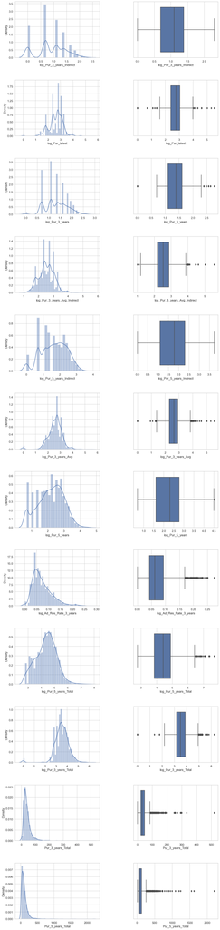

[figure not shown]

```python
import matplotlib.pyplot as plt
import seaborn as sns

fig, ax = plt.subplots(nrows=len(new_numerical_cols), ncols=2, figsize=(12,50))

for i in range(len(new_numerical_cols)):
    sns.distplot(data[new_numerical_cols[i]], ax=ax[i,0])
    sns.boxplot(data[new_numerical_cols[i]], ax=ax[i,1])

plt.tight_layout()
plt.subplots_adjust(wspace=0.4, hspace=0.4)

# Save figure
plt.savefig('numerical_distribution_and_boxplots.png')
plt.show()
```

## 4.2 Check Correlation between Numerical Variables

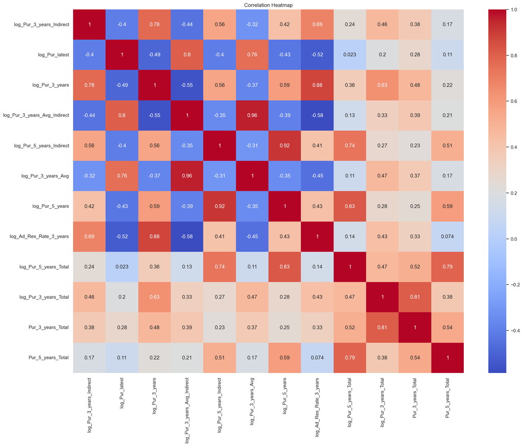

```python
import matplotlib.pyplot as plt
import seaborn as sns

corr = data[new_numerical_cols]

plt.figure(figsize=(20, 15))
sns.heatmap(corr.corr(), cmap="coolwarm", annot=True, square=False)
plt.title('Correlation Heatmap')

# Save figure
plt.savefig('correlation_heatmap.png')
plt.show()
```

# 5. Feature Selection

It is better we do not have numerical columns with high correlations as they confuse the machine learning algorithms. We can manually remove the highly-correlated features, or we can let the PCA handles that during the pre-processing.

# 6. Data PreProcessing

## 6.1 Check the Data for Missing Values

**Hint:**

1. Check which columns have missing values
2. Create a list of the name of the columns that have missing values `null_columns=data.columns[data.isnull().any()]`
3. Decide how you should handle the missing values for each column:

   a. For some numerical columns missing value simply means 0. b. We can fill missing values in a numerical column by replacing mean of the column, if the column is not skewed. If the column is skewed, median might be a better option.

```python
# 1-access the proportion of missing data

# print("Missing values distribution: ")
# print(round(data.isnull().mean() * 100, 2))  # round to 2 decimal places
# print("")
```

```python
data.isnull().sum()
```

```
Potential_Customer                 0
Cust_Last_Purchase              1882
Pur_3_years                        0
Pur_5_years                        0
Pur_3_years_Indirect               0
Pur_5_years_Indirect               0
Pur_latest                         0
Pur_3_years_Avg                    0
Pur_5_years_Avg                    0
Pur_3_years_Avg_Indirect         662
InAct_Last                         0
InAct_First                        0
Ad_Res_1_year                      0
Ad_Res_3_Year                      0
Ad_Res_5_Year                      0
Ad_Res_Ind_1_Year                  0
Ad_Res_Ind_3_Year                  0
Ad_Res_Ind_5_Year                  0
Status_Cust                        0
Status_Latest_Ad                   0
Age                              793
Gender                             0
Cust_Prop                          0
Cust_Ann_Income                    0
Pur_3_years_avg_total              0
Pur_3_years_Total                  0
Pur_5_years_Total                  0
Ad_Res_Rate_3_years                0
log_Pur_3_years_Indirect           0
log_Pur_latest                     0
log_Pur_3_years                    0
log_Pur_3_years_Avg_Indirect     662
log_Pur_5_years_Indirect           0
log_Pur_3_years_Avg                0
log_Pur_5_years                    0
log_Ad_Res_Rate_3_years            0
log_Pur_5_years_Total              0
log_Pur_3_years_Total              0
dtype: int64
```

```python
data['Cust_Last_Purchase'].fillna(0, inplace=True)

median = data['Pur_3_years_Avg_Indirect'].median()
data['Pur_3_years_Avg_Indirect'].fillna(median, inplace=True)

median = data['Age'].median()
data['Age'].fillna(median, inplace=True)

median = data['log_Pur_3_years_Avg_Indirect'].median()
data['log_Pur_3_years_Avg_Indirect'].fillna(median, inplace=True)
```

```python
print('Missing values in data:', data.isnull().sum())
```

```
Missing values in data: Potential_Customer              0
Cust_Last_Purchase              0
Pur_3_years                     0
Pur_5_years                     0
Pur_3_years_Indirect            0
Pur_5_years_Indirect            0
Pur_latest                      0
Pur_3_years_Avg                 0
Pur_5_years_Avg                 0
Pur_3_years_Avg_Indirect        0
InAct_Last                      0
InAct_First                     0
Ad_Res_1_year                   0
Ad_Res_3_Year                   0
Ad_Res_5_Year                   0
Ad_Res_Ind_1_Year               0
Ad_Res_Ind_3_Year               0
Ad_Res_Ind_5_Year               0
Status_Cust                     0
Status_Latest_Ad                0
Age                             0
Gender                          0
Cust_Prop                       0
Cust_Ann_Income                 0
Pur_3_years_avg_total           0
Pur_3_years_Total               0
Pur_5_years_Total               0
Ad_Res_Rate_3_years             0
log_Pur_3_years_Indirect        0
log_Pur_latest                  0
log_Pur_3_years                 0
log_Pur_3_years_Avg_Indirect    0
log_Pur_5_years_Indirect        0
log_Pur_3_years_Avg             0
log_Pur_5_years                 0
log_Ad_Res_Rate_3_years         0
log_Pur_5_years_Total           0
log_Pur_3_years_Total           0
dtype: int64
```

## 6.2 Separate X (features) and y (target)

**Attention:** Don't forget to exclude the column `Cust_Last_Purchase` from your analysis

```python
X = data.drop(['Potential_Customer', "Cust_Last_Purchase"], axis = 1)
y = data["Potential_Customer"]

print("X shape:", X.shape, "y shape:", y.shape)
```

```
X shape: (3618, 36) y shape: (3618,)
```

```python
#X = data.drop(['Potential_Customer'], axis = 1)
#y = data["Potential_Customer"]

#print("X shape:", X.shape, "y shape:", y.shape)
```

###### Create dummy

Now,let's Turned categorical variables into quantitative variable as most statistical models cannot take in the objects/strings as input

**Categorical => Numeric**  
Solution:

- Add dummy variables for each unique category
- Assign 0 or 1 or etc in each category

```python
# Remove Unknown gender as it bring no significance to our analysis

X['Gender'] = X['Gender'].replace('U', X['Gender'].mode()[0])
X["Gender"].unique()
```

```
['F', 'M']
Categories (2, object): ['F', 'M']
```

# note untuk diri sendiri X = pd.get_dummies(X, drop_first=True) will create a new DataFrame X by applying one-hot encoding to all the columns in the existing DataFrame X, and dropping the first column for each categorical variable. This is often used to avoid the "dummy variable trap" in linear regression models, where the presence of a column for each category can lead to multicollinearity.

```python
X = pd.get_dummies(X, drop_first=True)
X.head(1).T
```

|  | 0 |
| --- | --- |
| Pur_3_years | 2.000000 |
| Pur_5_years | 17.000000 |
| Pur_3_years_Indirect | 2.000000 |
| Pur_5_years_Indirect | 4.000000 |
| Pur_latest | 0.000000 |
| Pur_3_years_Avg | 7.500000 |
| Pur_5_years_Avg | 7.760000 |
| Pur_3_years_Avg_Indirect | 7.500000 |
| InAct_Last | 14.000000 |
| InAct_First | 110.000000 |
| Ad_Res_1_year | 32.000000 |
| Ad_Res_3_Year | 48.000000 |
| Ad_Res_5_Year | 73.000000 |
| Ad_Res_Ind_1_Year | 3.000000 |
| Ad_Res_Ind_3_Year | 12.000000 |
| Ad_Res_Ind_5_Year | 16.000000 |
| Age | 71.000000 |
| Cust_Ann_Income | 65957.000000 |
| Pur_3_years_avg_total | 15.000000 |
| Pur_3_years_Total | 15.000000 |
| Pur_5_years_Total | 131.920000 |
| Ad_Res_Rate_3_years | 0.032787 |
| log_Pur_3_years_Indirect | 1.098612 |
| log_Pur_latest | 0.000000 |
| log_Pur_3_years | 1.098612 |
| log_Pur_3_years_Avg_Indirect | 2.140066 |
| log_Pur_5_years_Indirect | 1.609438 |
| log_Pur_3_years_Avg | 2.140066 |
| log_Pur_5_years | 2.890372 |
| log_Ad_Res_Rate_3_years | 0.032261 |
| log_Pur_5_years_Total | 4.889747 |
| log_Pur_3_years_Total | 2.772589 |
| Status_Cust_Others | 0.000000 |
| Status_Cust_S | 0.000000 |
| Status_Latest_Ad_1 | 0.000000 |
| Gender_M | 0.000000 |
| Cust_Prop_U | 0.000000 |

## 6.3 Split data to train/test

Define X and y and split the data into 75/25 train/test set. Use random_state=42 and stratify=y

```python
X_train, X_test, y_train, y_test = train_test_split(X, y,
                                                    test_size=0.25,
                                                    random_state=42,
                                                    stratify=y)
```

## 6.4 Dummy Variables

Change categorical variables with numerical variabels

```python
 X_train = pd.get_dummies(X_train, drop_first=True).reset_index(drop=True)
 X_test = pd.get_dummies(X_test, drop_first=True).reset_index(drop=True)
```

```python
X.shape
```

```
(3618, 37)
```

## 6.5 Feature Scaling

```python
from sklearn.preprocessing import StandardScaler

sc = StandardScaler()

X_train_scaled = sc.fit_transform(X_train)
X_test_scaled = sc.fit_transform(X_test)
```

```python
X_train_scaled
```

```
array([[ 0.30892713,  1.90986605,  0.05513538, ...,  0.88063816,
        -0.85002334,  1.11451728],
       [ 0.76196459,  1.16549413,  1.27125164, ...,  0.88063816,
        -0.85002334, -0.89724944],
       [ 0.76196459, -0.32324971,  0.05513538, ..., -1.13554017,
         1.17643828, -0.89724944],
       ...,
       [-0.14411033,  1.05915528, -1.16098087, ...,  0.88063816,
         1.17643828, -0.89724944],
       [ 0.30892713, -0.32324971,  0.05513538, ..., -1.13554017,
        -0.85002334, -0.89724944],
       [-0.59714779,  1.05915528, -1.16098087, ...,  0.88063816,
        -0.85002334,  1.11451728]])
```

## 6.6 PCA on Numerical Columns only

1. Save the above scaled train and test data, as dataframe with proper column names

`X_train_sc=pd.DataFrame(scaler.transform(X_train), columns=X_train.columns)` 2. Separate train and test data for numerical columns only `train_PCA=X_train_sc[NewNumCols]`, `test_PCA=X_test_sc[NewNumCols]` 3. Define the number of components on `train_PCA` 4. Fit PCA on `train_PCA` 5. Transform `train_PCA` and `test_PCA` save it as `PCA_train` and `PCA_test`, and save them as DataFrame. Use `PCA_train.index=X_train.index` to make sure `PCA_train` have the same index with `X_train` because we need to concat this data to the dummy variables. Do the same on `PCA_test` 6. Concat `PCA_train` to the dummy variables in `X_train` save it as `X_train_pca` 7. Concat `PCA_test` to the dummy variables in `X_test` save it as `X_train_pca`

```python
from sklearn.decomposition import PCA
```

```python
categorical_cols
```

```
['Potential_Customer',
 'Status_Cust',
 'Status_Latest_Ad',
 'Gender',
 'Cust_Prop']
```

```python
# Save the above scaled train and test data, as dataframe with proper
# column names X_train_sc=pd.DataFrame(scaler.transform(X_train), columns=X_train.columns)

X_train_sc=pd.DataFrame(X_train_scaled, columns=X_train.columns)
X_test_sc = pd.DataFrame(X_test_scaled, columns=X_test.columns)
```

```python
categorical_cols
```

```
['Potential_Customer',
 'Status_Cust',
 'Status_Latest_Ad',
 'Gender',
 'Cust_Prop']
```

```python
# assigned a variable for our new (dummy) cat data

NewCatCols = ['Status_Cust_Others', 'Status_Cust_S', 'Status_Latest_Ad_1', 'Gender_M', 'Cust_Prop_U']
NewNumColsPCA = list(set(X_train.columns)-set(NewCatCols))
```

```python
len(NewNumColsPCA)
```

```
32
```

```python
train_PCA = X_train_sc[NewNumColsPCA]
test_PCA = X_test_sc[NewNumColsPCA]
```

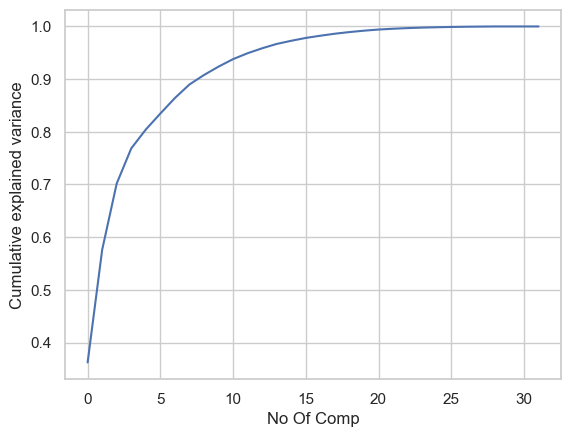

```python
import matplotlib.pyplot as plt
from sklearn.decomposition import PCA

pca = PCA().fit(train_PCA)
plt.plot(np.cumsum(pca.explained_variance_ratio_))
plt.xlabel("No Of Comp")
plt.ylabel("Cumulative explained variance")
plt.savefig('pca_plot.png')
plt.show()
```

```python
pca = PCA(n_components=20).fit(train_PCA)

PCA_train = pd.DataFrame(pca.transform(train_PCA))
PCA_train.index = X_train.index

PCA_test = pd.DataFrame(pca.transform(test_PCA))
PCA_test.index = X_test.index

X_train_pca = pd.concat([PCA_train, X_train[NewCatCols]], axis=1)
X_test_pca = pd.concat([PCA_test, X_test[NewCatCols]], axis=1)
```

```python
X_train_pca.shape
```

```
(2713, 25)
```

```python
X_test_pca.shape
```

```
(905, 25)
```

If the performance is satisfactory, we may not need to reduce dimensionality further. However, if the performance is not satisfactory or if the training time is too long, we can consider reducing the dimensionality further.

# 7. Objective 1: Machine Learning

**1. Design a predictive model to determine the potential customers who will purchase if you send the advertisement .** The target variable is `Potential_Customer`.

```
**Attention:** Because the column `Cust_Last_Purchase` relates to the target variable `Potential_Customer`, you need to exclude it from your model.
```

Apply various ML algorithms on the data, evaluate them after Grid Search and Cross Validation, and choose the best model.

```python
models = [
            ("Logistic Regression", LogisticRegression()),
            ("K-Nearest Neighbors", KNeighborsClassifier()),
            ("Decision Tree", DecisionTreeClassifier()),
            ("Support Vector Machine (RBF Kernel)", SVC()),
            ("Random Forest", RandomForestClassifier())       ]

Trained= {}

for t, model in models:
    Trained[t] = model.fit(X_train, y_train)
    print(f"{t} trained.")
```

```
Logistic Regression trained.
K-Nearest Neighbors trained.
Decision Tree trained.
Support Vector Machine (RBF Kernel) trained.
Random Forest trained.
```

for lr= higher c tells the model to give more weight to the training data. A lower value of C will indicate the model to give complexity more weight at the cost of fitting the data.

```python
# rujuk ML03b_CrossValidation_HyperParameterTuning_MC

param_grid = [

    ("Logistic Regression", {"C": [0.1, 10], "penalty": ["l1", "l2"]}),

    ("K-Nearest Neighbors", {"n_neighbors": [3, 5, 7]}),

    ("Decision Tree", {"max_depth": [3, 5, 7]}),

    ("Support Vector Machine (RBF Kernel)", {"C": [0.1, 1, 10], "gamma": ["scale", "auto"]}),

    ("Random Forest", {"n_estimators": [10, 50, 100], "max_depth": [3, 5, 7]})
]


best_models = {}

for t, model in Trained.items():
    grid = GridSearchCV(model, param_grid=dict(param_grid)[t], cv=5)
    grid.fit(X_train, y_train)
    best_models[t] = grid.best_estimator_
    print("Best Hyperparameters:", grid.best_params_)
    print(f"{t} trained.")
    print('***************************************************************')
```

```
Best Hyperparameters: {'C': 0.1, 'penalty': 'l2'}
Logistic Regression trained.
Best Hyperparameters: {'n_neighbors': 3}
K-Nearest Neighbors trained.
Best Hyperparameters: {'max_depth': 3}
Decision Tree trained.
Best Hyperparameters: {'C': 1, 'gamma': 'auto'}
Support Vector Machine (RBF Kernel) trained.
Best Hyperparameters: {'max_depth': 5, 'n_estimators': 100}
Random Forest trained.
```

```python
# print the models with its cross-validation score as %

for t, model in Trained.items():
    scores = cross_val_score(model, X.loc[:, X.columns != 'Cust_Last_Purchase'], y, cv=5)
    mean_score = scores.mean() * 100
    print(f"{t}: {mean_score:.2f}%")
```

```
Logistic Regression: 56.69%
K-Nearest Neighbors: 50.00%
Decision Tree: 51.22%
Support Vector Machine (RBF Kernel): 51.30%
Random Forest: 54.45%
```

```python
# print the models with its cross-validation score as %
# and select the best model

scores = []
for t, model in Trained.items():
    mean_score = cross_val_score(model, X.loc[:, X.columns != 'Cust_Last_Purchase'], y, cv=5).mean() * 100
    scores.append(mean_score)
    print(f"{t}: {mean_score:.2f}%")

best_model_index = np.argmax(scores)    # np.argmax(scores) = return max value in scores
best_model_name = list(Trained.keys())[best_model_index]
print(f"\nThe best model is: {best_model_name}")
```

```
Logistic Regression: 56.69%
K-Nearest Neighbors: 50.00%
Decision Tree: 51.66%
Support Vector Machine (RBF Kernel): 51.30%
Random Forest: 54.17%

The best model is: Logistic Regression
```

```python
X_train_pca.columns
```

```
Index([                   0,                    1,                    2,
                          3,                    4,                    5,
                          6,                    7,                    8,
                          9,                   10,                   11,
                         12,                   13,                   14,
                         15,                   16,                   17,
                         18,                   19, 'Status_Cust_Others',
            'Status_Cust_S', 'Status_Latest_Ad_1',           'Gender_M',
              'Cust_Prop_U'],
      dtype='object')
```

```python
X_train_pca.columns = X_train_pca.columns.astype(str)
X_test_pca.columns = X_test_pca.columns.astype(str)

lr = LogisticRegression(C=0.1, penalty='l2', random_state=42)
lr.fit(X_train_pca, y_train)
y_pred = lr.predict(X_test_pca)
```

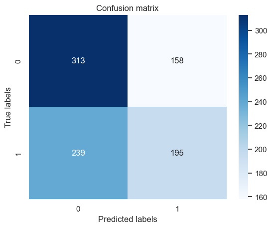

```python
cm = confusion_matrix(y_test, y_pred)

sns.heatmap(cm, annot=True, fmt='.0f', cmap='Blues')
plt.title('Confusion matrix')
plt.xlabel('Predicted labels')
plt.ylabel('True labels')
plt.show()
plt.savefig('confusion_matrix.png')
```

```python
confusion_matrix(y_test, y_pred)
```

```
array([[313, 158],
       [239, 195]], dtype=int64)
```

Finally, if we wish, we can use the best model and show the fit to our data using code from before:

```python
from sklearn.metrics import confusion_matrix, accuracy_score, precision_score, recall_score,f1_score


print("Accuracy: ", round(accuracy_score(y_test, y_pred), 2))
print("Precision: ", round(precision_score(y_test, y_pred), 2))
print("Recall: ", round(recall_score(y_test, y_pred), 2))
print("F-score:", round(f1_score(y_test,y_pred), 2))
```

```
Accuracy:  0.56
Precision:  0.55
Recall:  0.45
F-score: 0.5
```